# Bayesian GLMM Part1

Murray Logan

28 December, 2020

# Preparations

Load the necessary libraries

```r
library(rstanarm)   #for fitting models in STAN
library(brms)       #for fitting models in STAN
library(coda)       #for diagnostics
library(bayesplot)  #for diagnostics
library(ggmcmc)     #for MCMC diagnostics
library(rstan)      #for interfacing with STAN
library(emmeans)    #for marginal means etc
library(broom)      #for tidying outputs
library(DHARMa)     #for residual diagnostics
library(tidybayes)  #for more tidying outputs
library(ggeffects)  #for partial plots
library(broom.mixed)
library(tidyverse)  #for data wrangling etc
```

# Scenario

A plant pathologist wanted to examine the effects of two different strengths of tobacco virus on the number of lesions on tobacco leaves. She knew from pilot studies that leaves were inherently very variable in response to the virus. In an attempt to account for this leaf to leaf variability, both treatments were applied to each leaf. Eight individual leaves were divided in half, with half of each leaf inoculated with weak strength virus and the other half inoculated with strong virus. So the leaves were blocks and each treatment was represented once in each block. A completely randomised design would have had 16 leaves, with 8 whole leaves randomly allocated to each treatment.

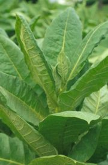

Tobacco plant

Format of tobacco.csv data files

| LEAF | TREAT | NUMBER |
| --- | --- | --- |
| 1 | Strong | 35.898 |
| 1 | Week | 25.02 |
| 2 | Strong | 34.118 |
| 2 | Week | 23.167 |
| 3 | Strong | 35.702 |
| 3 | Week | 24.122 |
| ... | ... | ... |

| **LEAF** | The blocking factor - Factor B |
| --- | --- |
| **TREAT** | Categorical representation of the strength of the tobacco virus - main factor of interest Factor A |
| **NUMBER** | Number of lesions on that part of the tobacco leaf - response variable |

# Read in the data

```r
tobacco = read_csv('../public/data/tobacco.csv', trim_ws=TRUE)
glimpse(tobacco)
```

```
## Rows: 16
## Columns: 3
## $ LEAF      <chr> "L1", "L1", "L2", "L2", "L3", "L3", "L4", "L4", "L5", "L5",…
## $ TREATMENT <chr> "Strong", "Weak", "Strong", "Weak", "Strong", "Weak", "Stro…
## $ NUMBER    <dbl> 35.89776, 25.01984, 34.11786, 23.16740, 35.70215, 24.12191,…
```

# Exploratory data analysis

Along with ensuring that all categorical variables are specifically declared as factors, if we intend to use either `rstanarm` or `brms`, we also need to ensure that all **varying** effects are also declared as factors.

```r
tobacco = tobacco %>% mutate(LEAF=factor(LEAF),
                             TREATMENT=factor(TREATMENT))
head(tobacco)
```

| LEAF | TREATMENT | NUMBER |
| --- | --- | --- |
| L1 | Strong | 35.89776 |
| L1 | Weak | 25.01984 |
| L2 | Strong | 34.11786 |
| L2 | Weak | 23.16740 |
| L3 | Strong | 35.70215 |
| L3 | Weak | 24.12191 |

To explore the assumptions of homogeneity of variance and normality, a boxplot of each Treatment level is appropriate.

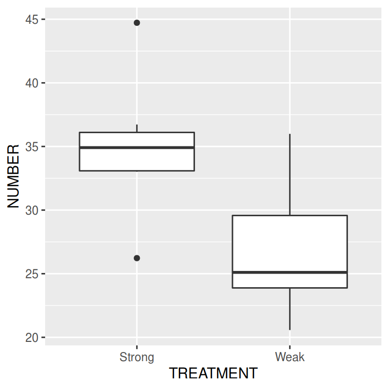

```r
ggplot(tobacco,  aes(y=NUMBER,  x=TREATMENT)) +
  geom_boxplot()
```

**Conclusions:**

- both normality and homogeneity of variance seem satisfied

It can also be useful to get a sense of the consistency across blocks (LEAF). That is, do all Leaves have a similar baseline level of lesion susceptibility and do they respond similarly to the treatment.

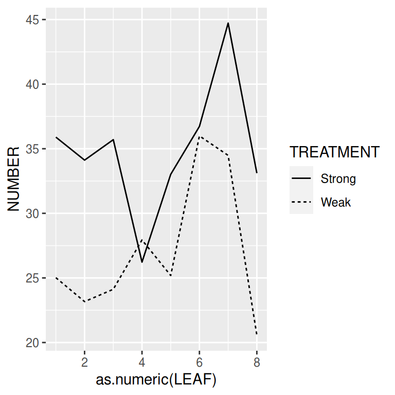

```r
ggplot(tobacco,  aes(y=NUMBER,  x=as.numeric(LEAF))) +
  geom_line(aes(linetype=TREATMENT))
```

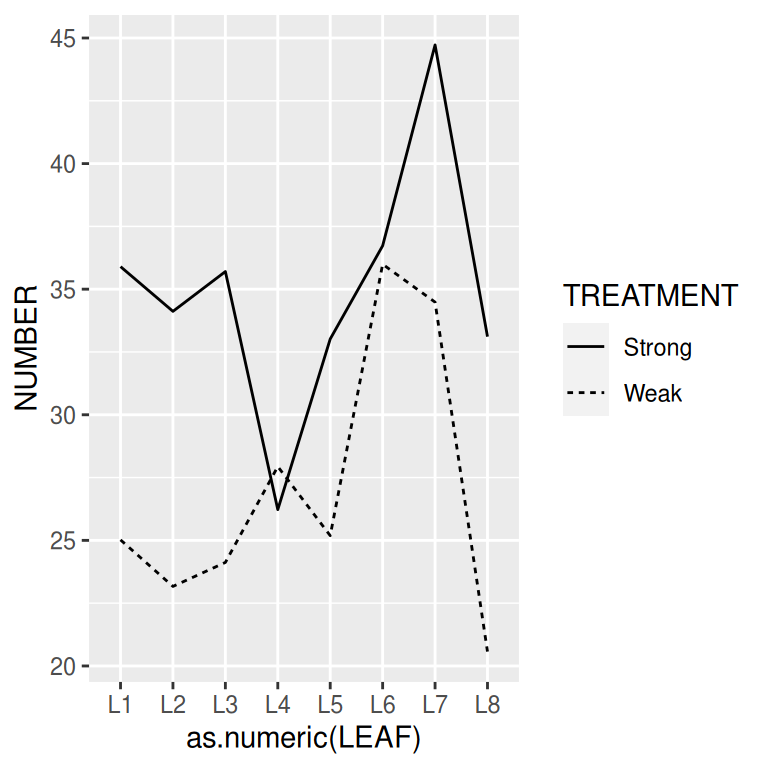

```r
## If we want to retain the original LEAF labels
ggplot(tobacco,  aes(y=NUMBER,  x=as.numeric(LEAF))) +
  geom_blank(aes(x=LEAF)) +
  geom_line(aes(linetype=TREATMENT))
```

**Conclusions:**

- it is clear that some leaves are more susceptible to lesions (e.g. Leaf 7) than other leaves (e.g. Leaf 4)
- most leaves (other than Leaf 4 and 6) have a similar response to the Treatments - that is most have higher number of lesions from the Strong Treatment than the Weak Treatment.

Given that there are only two levels of Treatment (Strong and Weak), it might be easier to visualise the differences in baselines and effect consistency by plotting as:

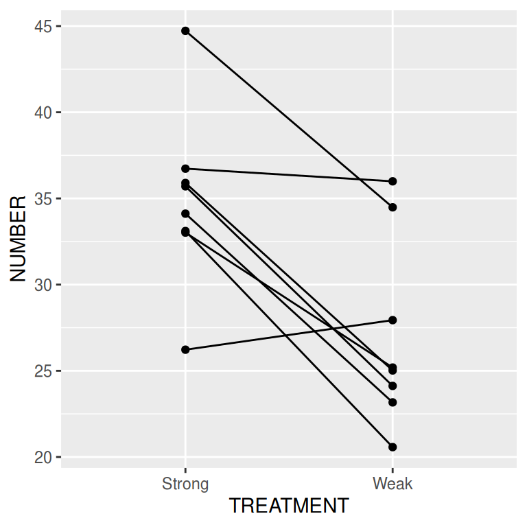

```r
ggplot(tobacco,  aes(y=NUMBER,  x=TREATMENT,  group=LEAF)) +
  geom_point() +
  geom_line(aes(x=as.numeric(TREATMENT)))
```

**Conclusions:**

- this figure reiterates the points made earlier about the varying baselines and effect consistency.

The above figure also serves as a good way to visualise certain aspects of mixed effects models. When we fit a mixed effects model that includes a random blocking effect (in this case LEAF), we are indicating that we are allowing there to be a different intercept for each block (LEAF). In the current case, the intercept will represent the first Treatment level (Strong). So the random effect is specifying that the intercept can vary from Leaf to Leaf.

We can think of the model as having two tiers (a hierarchy), where the tiers of the hierarchy represent progressively smaller (typically) spatial scales. In the current example, the largest spatial units are the leaves (blocking factor). Within the leaves, there are the two Treatments (Strong and Weak) and within the Treatments are the individual observations.

From a frequentist perspective, this model might be referred to as a mixed effects model in which the `TREATMENT` is a ‘fixed’ effect and the `LEAF` is a ‘random’ effect. Such terminology is inconsistent in a Bayesian context since all parameters are ‘random’. Instead, these would be referred to as *population-level* and *group-level* effects respectively. Group-level effects are so called because they are effects that differ within each group (e.g. level of a blocking factor), whereas population effects are those that have been pooled across all groups.

Model formula:
$$y_i \sim{} \mathcal{N}(\mu_i, \sigma^2)\\
\mu_i =\bf{X_i}\boldsymbol{\beta} + \bf{Z_i}\boldsymbol{\gamma} \\
\beta_0 \sim{} \mathcal{N}(31, 10)\\
\beta_1 \sim{} \mathcal{N}(0, 10)\\
\boldsymbol{\gamma} \sim{} \mathcal{N}(0, \boldsymbol{\Sigma})\\
\boldsymbol{\Sigma} = \boldsymbol{D}({\sigma_l})\boldsymbol{\Omega}\boldsymbol{D}({\sigma_l})\\
\boldsymbol{\Omega} \sim{} LKJ(\zeta)\\
\sigma_j^2 \sim{} \Gamma(1,1)\\
\sigma^2 \sim{} \mathcal{Cauchy}(0,2)$$

where:

- $\bf{X}$ is the model matrix representing the overall intercept and effects of the treatment on the number of lesions.
- $\boldsymbol{\beta}$ is a vector of the population-level effects parameters to be estimated.
- $\boldsymbol{\gamma}$ is a vector of the group-level effect parameters
- $\bf{Z}$ represents a cell means model matrix for the random intercepts (and possibly random slopes) associated with leaves.
- the population-level intercept ($\beta_0$) has a gaussian prior with location of 31 and scale of 10
- the population-level effect ($\beta_1$) has a gaussian prior with location of 0 and scale of 10
- the group-level effects are assumed to sum-to-zero and be drawn from a gaussian distribution with mean of 0 and covariance of $\Sigma$
- $\boldsymbol{\Sigma}$ is the variance-covariance matrix between the groups (individual leaves). It turns out that it is difficult to apply a prior on this covariance matrix, so instead, the covariance matrix is decomposed into a correlation matrix ($\boldsymbol{\Omega}$) and a vector of variances ($\boldsymbol{\sigma_l}$) which are the diagonals ($\boldsymbol{D}$) of the covariance matrix.
- $\boldsymbol{\Omega}$
  $$\gamma \sim{} N(0,\Sigma)\\
  \Sigma -> \Omega, \tau\\$$
  where $\Sigma$ is a covariance matrix.

It turns out that it is difficult to apply a prior on a covariance matrix, so instead, we decompose the covariance matrix into a correlation matrix and variance.

- Covariance matrix can be decomposed into a correlation matrix and a vector of variances
- The variances can be further decomposed into the product of a simplex vector (which is a probability vector, non-negative and sums to 1) and the trace (product of the order of the matrix and the scale of the scale parameter, also the sum of its diagonal elements) of a matrix. Each element of the simplex vector represents the proportion of the trace that is attributable to the corresponding variable.
- A prior on all the above is a decov (decomposition of covariance) function
- The prior on the correlation matrix is called LKJ
- density is proportional to the determinant of the correlation matrix raised to the power of the positive regularization paramter minus one.
- The prior on the simplex vector is a symmetric Dirichlet prior which has a single (positive) concentration parameter (default of 1 implying the prior is jointly uniform over the same of simplex vectors of that size) A symmetric Dirichlet prior is used for the simplex vector. The Dirichlet prior has a single (positive) concentration parameter
- The positive scale paramter has a gamma prior (with default shape and scale of 1 - implying a unit-exponential distribution)
- alternatively, the lkj prior can be used for covariance.
- as with decov, it decomposes into correlation and variances, however the variances are not further decomosed into a simplex vector and trace.
- instead the standard deviations (variance squared) for each of the group specific paramters are given half student-t distribution with scale and df paramters specified through the scale (default 10) and df (default 1) arguments of the lkj function.
- the lkj prior is similar, yet faster than decov

# Fit the model

## rstanarm

### Using default priors

In `rstanarm`, the default priors are designed to be weakly informative. They are chosen to provide moderate regularlization (to help prevent overfitting) and help stabalise the computations.

```r
tobacco.rstanarm = stan_glmer(NUMBER ~ (1|LEAF) + TREATMENT, data=tobacco,
                        family=gaussian(),
                         iter = 5000, warmup = 2000,
                         chains = 3, thin = 5, refresh = 0)
```

```r
prior_summary(tobacco.rstanarm)
```

```
## Priors for model 'tobacco.rstanarm'
## ------
## Intercept (after predictors centered)
##   Specified prior:
##     ~ normal(location = 31, scale = 2.5)
##   Adjusted prior:
##     ~ normal(location = 31, scale = 16)
##
## Coefficients
##   Specified prior:
##     ~ normal(location = 0, scale = 2.5)
##   Adjusted prior:
##     ~ normal(location = 0, scale = 32)
##
## Auxiliary (sigma)
##   Specified prior:
##     ~ exponential(rate = 1)
##   Adjusted prior:
##     ~ exponential(rate = 0.15)
##
## Covariance
##  ~ decov(reg. = 1, conc. = 1, shape = 1, scale = 1)
## ------
## See help('prior_summary.stanreg') for more details
```

This tells us:

```r
2.5*sd(tobacco$NUMBER)
```

```
## [1] 16.35115
```

- for the coefficients (in this case, just the difference between strong and weak innoculation), the default prior is a normal prior centered around 0 with a standard deviation of 2.5. This is then adjusted for the scale of the data by multiplying the 2.5 by the ratio of the standard deviation of the response by the stanard devation of the numerical dummy variables for the predictor (then rounded).

```r
2.5*sd(tobacco$NUMBER)/sd(model.matrix(~TREATMENT, tobacco)[, 2])
```

```
## [1] 31.66386
```

- the auxillary prior represents whatever additional prior is required for the nominated model. In the case of a Gaussian model, this will be $\sigma$, for negative binomial, it will be the reciprocal of dispersion, for gamma, it will be shape, etc . By default in `rstanarm`, this is a exponential with a rate of 1 which is then adjusted by devision with the standard deviation of the response.

```r
1/sd(tobacco$NUMBER)
```

```
## [1] 0.1528945
```

### Assessing priors

Lets now run with priors only so that we can explore the range of values they allow in the posteriors.

```r
tobacco.rstanarm1 <- update(tobacco.rstanarm,  prior_PD=TRUE)
```

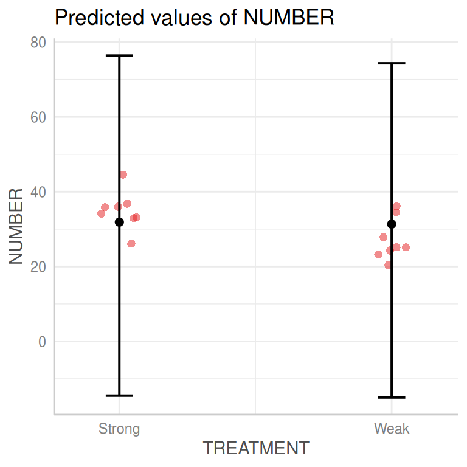

```r
ggpredict(tobacco.rstanarm1) %>% plot(add.data=TRUE)
```

**Conclusions:**

- we see that the range of predictions is faily wide and the predicted means could range from a small negative number to a relatively large positive number.

### Defining priors

The following link provides some guidance about defining priors. [https://github.com/stan-dev/stan/wiki/Prior-Choice-Recommendations]

When defining our own priors, we typically do not want them to be scaled.

If we wanted to define our own priors that were less vague, yet still not likely to bias the outcomes, we could try the following priors (mainly plucket out of thin air):

- $\beta_0$: normal centered at 35 with a standard deviation of 10
- $\beta_1$: normal centered at 0 with a standard deviation of 10
- $\sigma$: exponential with rate of 0.1
- $\Sigma$: decov with:
  - regularization: the exponent for a LKJ prior on the correlation matrix. A value of 1 (default) implies a joint uniform prior
  - concentration: the concentration parameter for a symmetric Dirichlet distribution. A value of 1 (default) implies a joint uniform distribution
  - shape and scale: the shape and scale parameters for a gamma prior on the scale and scale parameters of the decov prior. A value of 1 for both (default) simplifies the gamma prior to a unit-exponential distribution.

I will also overlay the raw data for comparison.

```r
tobacco.rstanarm2= stan_glmer(NUMBER ~ (1|LEAF) + TREATMENT, data=tobacco,
                              family=gaussian(),
                              prior_intercept = normal(35, 10, autoscale=FALSE),
                              prior = normal(0, 10, autoscale=FALSE),
                              prior_aux=rstanarm::exponential(0.1, autoscale=FALSE),
                              prior_covariance=decov(1, 1, 1, 1),
                              prior_PD=TRUE,
                              iter = 5000, warmup = 1000,
                              chains = 3, thin = 5, refresh = 0
                              )
```

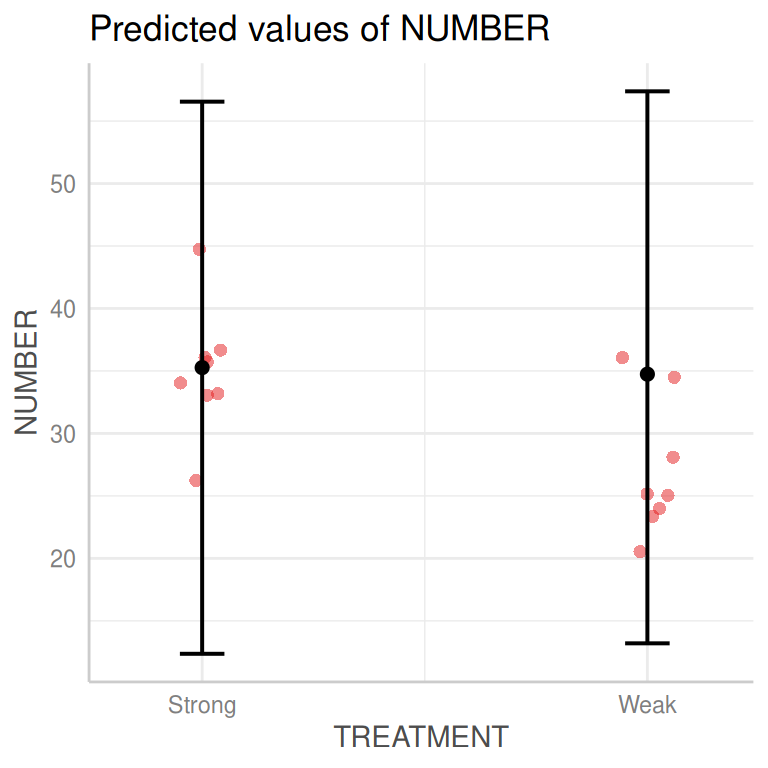

```r
ggpredict(tobacco.rstanarm2) %>%
  plot(add.data=TRUE)
```

## brms

### Using default priors

In `brms`, the default priors are designed to be weakly informative. They are chosen to provide moderate regularlization (to help prevent overfitting) and help stabalise the computations.

Unlike `rstanarm`, `brms` models must be compiled before they start sampling. For most models, the compilation of the stan code takes around 45 seconds.

```r
tobacco.brm = brm(bf(NUMBER ~ (1|LEAF) + TREATMENT), data=tobacco,
              family=gaussian(),
              iter = 5000, warmup = 1000,
              chains = 3, thin = 5, refresh = 0)
```

```r
prior_summary(tobacco.brm)
```

```
##                    prior     class          coef group resp dpar nlpar bound       source
##                   (flat)         b                                                default
##                   (flat)         b TREATMENTWeak                             (vectorized)
##  student_t(3, 33.1, 6.5) Intercept                                                default
##     student_t(3, 0, 6.5)        sd                                                default
##     student_t(3, 0, 6.5)        sd                LEAF                       (vectorized)
##     student_t(3, 0, 6.5)        sd     Intercept  LEAF                       (vectorized)
##     student_t(3, 0, 6.5)     sigma                                                default
```

# Fit the model

```r
ggplot(tobacco, aes(y=NUMBER,x=TREATMENT)) + geom_boxplot()
ggplot(tobacco, aes(y=NUMBER,x=as.numeric(LEAF), linetype=TREATMENT)) + geom_line()
ggplot(tobacco, aes(y=NUMBER,x=TREATMENT, group=LEAF)) + geom_line()

tobacco.rstanarm <- stan_glmer(NUMBER~(1|LEAF)+TREATMENT, data=tobacco,
                           family=gaussian,refresh=0,
                            prior_PD=TRUE,
                           chains=3, iter=5000, warmup=2000, thin=5)
prior_summary(tobacco.rstanarm)
## decov is prior on covariance

tobacco.rstanarm <- stan_glmer(NUMBER~(1|LEAF)+TREATMENT, data=tobacco,
                            family=gaussian,refresh=0,
                            prior_intercept=normal(35, 10, autoscale=FALSE),
                            prior=normal(0, 10, autoscale=FALSE),
                            prior_aux=rstanarm::exponential(0.1, autoscale=FALSE),
                            prior_covariance=decov(1, 1, 1, 1),
                            prior_PD=TRUE,
                           chains=3, iter=5000, warmup=2000, thin=5)

prior_summary(tobacco.rstanarm)

ggpredict(tobacco.rstanarm) %>% plot(add.data=TRUE)

tobacco.rstanarm <- update(tobacco.rstanarm, prior_PD=FALSE)

ggpredict(tobacco.rstanarm) %>% plot(add.data=TRUE)

posterior_vs_prior(tobacco.rstanarm, color_by='vs', group_by=TRUE,
                   facet_args=list(scales='free_y'))



tobacco.rstanarm1 <- stan_glmer(NUMBER~(TREATMENT|LEAF)+TREATMENT, data=tobacco,
                            family=gaussian,refresh=0,
                            prior_PD=TRUE,
                           chains=3, iter=5000, warmup=2000, thin=5)
prior_summary(tobacco.rstanarm1)

ggpredict(tobacco.rstanarm1) %>% plot(add.data=TRUE)

tobacco.rstanarm1 <- stan_glmer(NUMBER~(TREATMENT|LEAF)+TREATMENT, data=tobacco,
                            family=gaussian,refresh=0,
                            prior_intercept=normal(35, 10, autoscale=FALSE),
                            prior=normal(0, 10, autoscale=FALSE),
                            prior_aux=rstanarm::exponential(0.1, autoscale=FALSE),
                            prior_covariance=decov(1, 1, 1, 1),
                            prior_PD=TRUE,
                           chains=3, iter=5000, warmup=2000, thin=5)

tobacco.rstanarm1 <- stan_glmer(NUMBER~(TREATMENT|LEAF)+TREATMENT, data=tobacco,
                            family=gaussian,refresh=0,
                            prior_intercept=normal(35, 10, autoscale=FALSE),
                            prior=normal(0, 10, autoscale=FALSE),
                            prior_aux=rstanarm::exponential(0.1, autoscale=FALSE),
                            prior_covariance=decov(1, 1, 1, 1),
                            prior_PD=TRUE,
                            chains=3, iter=5000, warmup=2000, thin=5,
                            adapt_delta=0.99)

ggpredict(tobacco.rstanarm1) %>% plot(add.data=TRUE)
tobacco.rstanarm1 <- update(tobacco.rstanarm1, prior_PD=FALSE)
tobacco.rstanarm1 <- update(tobacco.rstanarm1, prior_PD=FALSE, adapt_delta=0.99)

ggpredict(tobacco.rstanarm1) %>% plot(add.data=TRUE)

posterior_vs_prior(tobacco.rstanarm1, color_by='vs', group_by=TRUE,
                   facet_args=list(scales='free_y'))


plot(tobacco.rstanarm1,  'mcmc_trace')
plot(tobacco.rstanarm1,  'mcmc_acf_bar')
plot(tobacco.rstanarm1,  'mcmc_rhat_hist')
plot(tobacco.rstanarm1,  'mcmc_neff_hist')

pp_check(tobacco.rstan)
pp_check(tobacco.rstan, group='TREATMENT', plotfun='violin_grouped')

## tobacco.rstan1 <- stan_glmer(NUMBER~(TREATMENT|LEAF)+TREATMENT, data=tobacco,
##                            family=gaussian,refresh=0,
##                            chains=3, iter=5000, warmup=2000, thin=5)

## tobacco.rstan1 <- stan_glmer(NUMBER~(TREATMENT|LEAF)+TREATMENT, data=tobacco,
##                            family=gaussian,refresh=0,
##                            chains=3, iter=5000, warmup=2000, thin=5,
##                            adapt_delta=0.99)

## plot(tobacco.rstan1,  'mcmc_trace')
## plot(tobacco.rstan1,  'mcmc_acf_bar')
## plot(tobacco.rstan1,  'mcmc_rhat_hist')
## plot(tobacco.rstan1,  'mcmc_neff_hist')


preds <- posterior_predict(tobacco.rstanarm1,  nsamples=250,  summary=FALSE)
tobacco.resids <- createDHARMa(simulatedResponse = t(preds),
                            observedResponse = tobacco$NUMBER,
                            fittedPredictedResponse = apply(preds, 2, median),
                            integerResponse=FALSE)
plot(tobacco.resids)

(l.1 <- loo(tobacco.rstanarm))
(l.2 <- loo(tobacco.rstanarm1))
loo_compare(l.1, l.2)

preds <- posterior_predict(tobacco.rstanarm,  nsamples=250,  summary=FALSE)
tobacco.resids <- createDHARMa(simulatedResponse = t(preds),
                            observedResponse = tobacco$NUMBER,
                            fittedPredictedResponse = apply(preds, 2, median))
plot(tobacco.resids)


ggpredict(tobacco.rstanarm) %>% plot
##ggemmeans(tobacco.rstan, ~TREATMENT) %>% plot

summary(tobacco.rstanarm)
tidyMCMC(tobacco.rstanarm$stanfit,conf.int=TRUE, conf.method='HPDinterval',
         rhat=TRUE, ess=TRUE, estimate.method='median') %>%
  data.frame

bayes_R2(tobacco.rstanarm, re.form=NA) %>% median_hdci
bayes_R2(tobacco.rstanarm, re.form=~(1|LEAF)) %>% median_hdci

newdata = emmeans(tobacco.rstanarm, ~TREATMENT) %>%
    gather_emmeans_draws() %>%
    spread(key=TREATMENT, value=.value)
newdata
newdata = newdata %>% mutate(Eff = Strong-Weak,
                   PEff = 100*(Strong-Weak)/Weak)
newdata %>% dplyr::select(Eff,PEff) %>% median_hdci
newdata %>% summarize(Prob = sum(PEff>0)/n())
newdata %>% summarize(Prob = sum(PEff>10)/n())
hypothesis(newdata,  'PEff>0')
hypothesis(newdata,  'PEff>10')


newdata = emmeans(tobacco.rstanarm, ~TREATMENT) %>% as.data.frame
head(newdata)
ggplot(newdata, aes(y=emmean, x=TREATMENT)) +
    geom_pointrange(aes(ymin=lower.HPD, ymax=upper.HPD))
```

```r
tobacco = tobacco %>% mutate(LEAF=factor(LEAF),
                             TREATMENT=factor(TREATMENT))
head(tobacco)

ggplot(tobacco, aes(y=NUMBER,x=TREATMENT)) + geom_boxplot()
ggplot(tobacco, aes(y=NUMBER,x=as.numeric(LEAF), linetype=TREATMENT)) + geom_line()
ggplot(tobacco, aes(y=NUMBER,x=as.numeric(LEAF), linetype=TREATMENT)) + geom_blank(aes(x=LEAF)) + geom_line()

tobacco.form <- bf(NUMBER~(1|LEAF)+TREATMENT,  family=gaussian)

tobacco.brms <- brm(tobacco.form, data=tobacco,
                           refresh=0,
                           chains=3, iter=5000, warmup=2000, thin=5)
tobacco.brms <- brm(tobacco.form, data=tobacco,
                           refresh=0,
                    chains=3, iter=5000, warmup=2000, thin=5,
                    control=list(adapt_delta=0.99))


mcmc_plot(tobacco.brms,  type='trace')
mcmc_plot(tobacco.brms,  type='acf_bar')
mcmc_plot(tobacco.brms,  type='rhat_hist')
mcmc_plot(tobacco.brms,  type='neff_hist')

tobacco.form <- bf(NUMBER~(TREATMENT|LEAF)+TREATMENT,  family=gaussian)
tobacco.brms1 <- brm(tobacco.form, data=tobacco,
                     refresh=0,
                     chains=3, iter=5000, warmup=2000, thin=5,
                     control=list(adapt_delta=0.99))

mcmc_plot(tobacco.brms1,  type='trace')
mcmc_plot(tobacco.brms1,  type='acf_bar')
mcmc_plot(tobacco.brms1,  type='rhat_hist')
mcmc_plot(tobacco.brms1,  type='neff_hist')

(l.1 <- loo(tobacco.brms))
(l.2 <- loo(tobacco.brms1))
loo_compare(l.1, l.2)


preds <- posterior_predict(tobacco.brms,  nsamples=250,  summary=FALSE)
tobacco.resids <- createDHARMa(simulatedResponse = t(preds),
                            observedResponse = tobacco$NUMBER,
                            fittedPredictedResponse = apply(preds, 2, median))
plot(tobacco.resids)

preds <- posterior_predict(tobacco.brms1,  nsamples=250,  summary=FALSE)
tobacco.resids <- createDHARMa(simulatedResponse = t(preds),
                            observedResponse = tobacco$NUMBER,
                            fittedPredictedResponse = apply(preds, 2, median),
                            integerResponse = TRUE)
plot(tobacco.resids)


ggpredict(tobacco.brms1) %>% plot
##ggemmeans(tobacco.rstan, ~TREATMENT) %>% plot

summary(tobacco.brms)
tidyMCMC(tobacco.brms1$fit,
         conf.int=TRUE, conf.method='HPDinterval',
         rhat=TRUE, ess=TRUE,
         estimate.method='median')

bayes_R2(tobacco.brms1, re.form=~(1|LEAF), summary=FALSE) %>% median_hdi
bayes_R2(tobacco.brms, re.form=~(1|LEAF), summary=FALSE) %>% median_hdi
bayes_R2(tobacco.brms1, re.form=~(TREATMENT|LEAF), summary=FALSE) %>% median_hdi
bayes_R2(tobacco.brms1, re.form=NA,  summary=FALSE) %>% median_hdi
bayes_R2(tobacco.brms1, re.form=NA,  summary=FALSE) %>% median_hdi

newdata = emmeans(tobacco.brms1, ~TREATMENT) %>%
    gather_emmeans_draws() %>%
    spread(key=TREATMENT, value=.value)
newdata
newdata = newdata %>% mutate(Eff = Strong-Weak,
                   PEff = 100*(Strong-Weak)/Weak)
newdata %>% dplyr::select(Eff,PEff) %>% median_hdi
newdata %>% summarize(Prob = sum(PEff>0)/n())
newdata %>% summarize(Prob = sum(PEff>20)/n())
hypothesis(newdata,  'PEff>0')
newdata %>% summarize(Prob = sum(PEff>50)/n())
hypothesis(newdata,  'PEff>20')


newdata = emmeans(tobacco.brms1, ~TREATMENT) %>% as.data.frame
head(newdata)
ggplot(newdata, aes(y=emmean, x=TREATMENT)) +
    geom_pointrange(aes(ymin=lower.HPD, ymax=upper.HPD))
```